# An intro to data visualization

by William Gearty  
Presented at the  
North American Paleontological Convention 2024

[figure not shown]

## Schedule

10 - 10:15 AM: Theory of data visualization  
10:15 - 10:45 AM: Practical data visualization

## Theory of data visualization

1. What is data visualization?
2. Basic design principles (color & font)
3. Picking a graph type
4. Common mistakes
5. File types

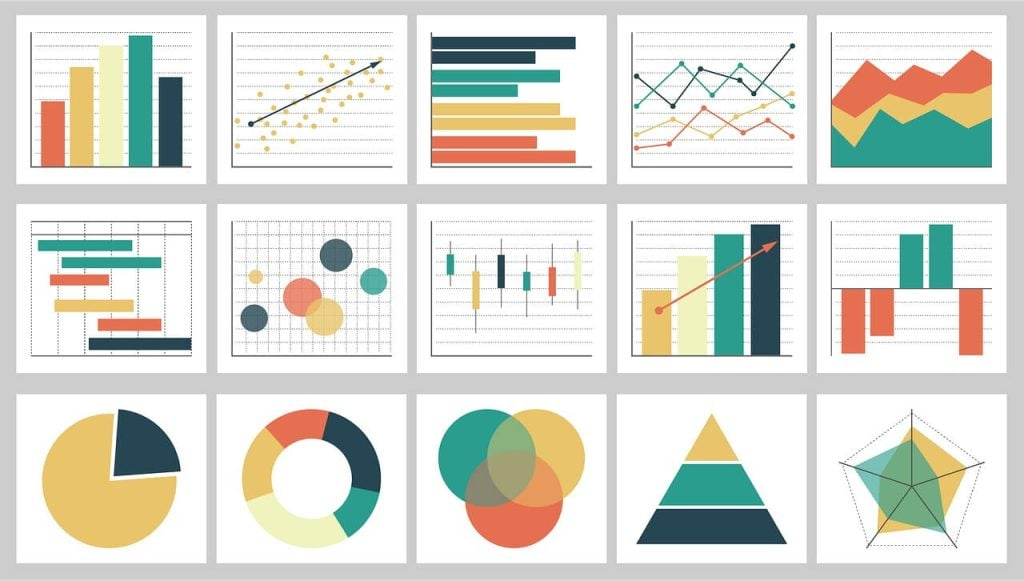

# What is data visualization?

## What is data visualization?

The representation of data through the use of **graphs** and **figures**.  
Often the data is **complex**, but the representation should be **approachable** and **easy-to-understand**.

## What is data visualization?

For example, here is some **data**:

[figure not shown]

(even this is a data visualization)

## What is data visualization?

And here is a **data visualization** of that data:

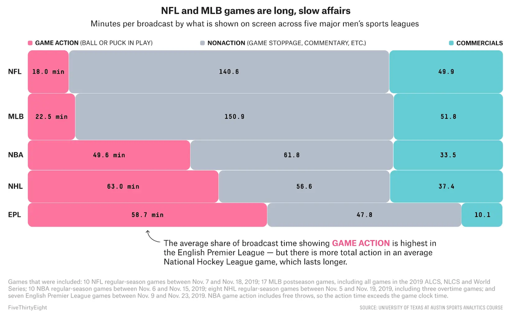

## What is data visualization?

Here’s another example. What data is being represented?

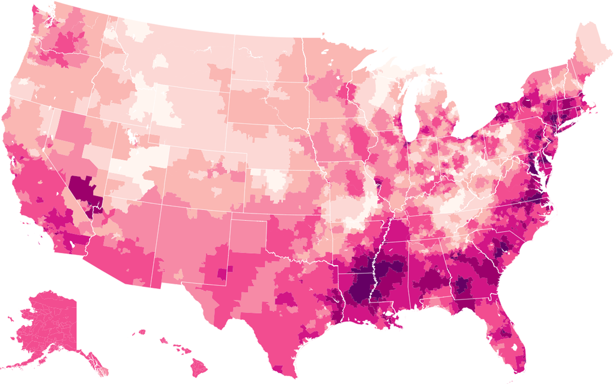

# Basic design principles

## Basic design principles

- Color
- Type (aka font)
- Positioning (R takes care of most of this)

## Color

### Lots of colors exist!

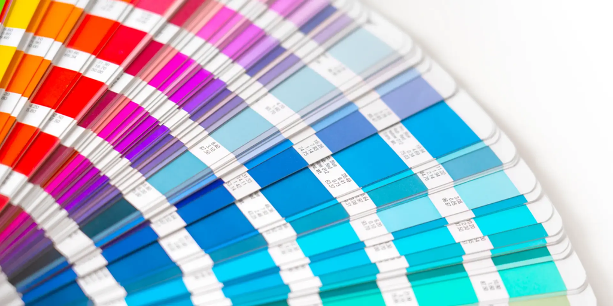

## Color

### Picking colors

- Value (lightness/darkness)

[figure not shown]

## Color

### Picking colors

- Temperature (cool vs warm)

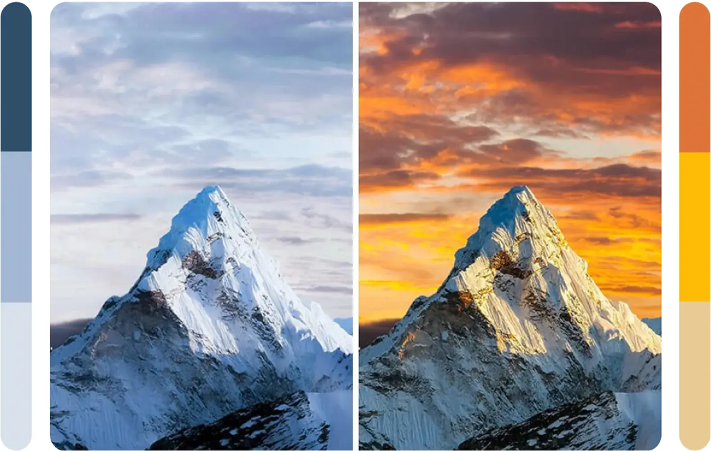

## Color

### Picking colors

- Saturation (intensity of color)

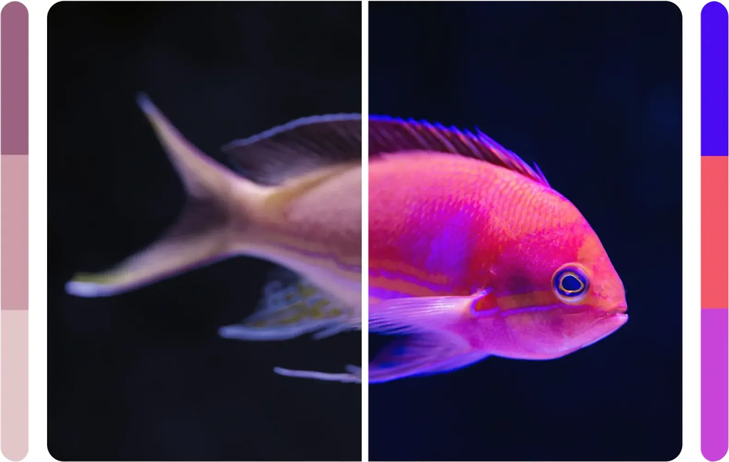

## Color

### Picking colors

- Palettes (collections of colors that work well together)

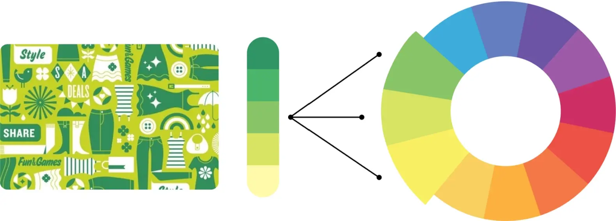

## Color

### Picking colors

- Palettes (collections of colors that work well together)

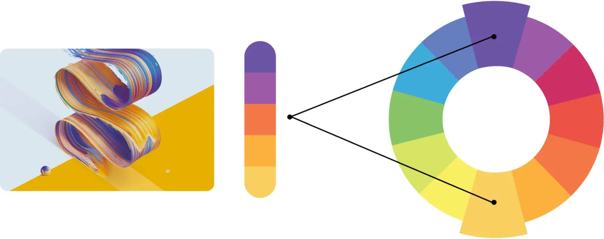

## Color

### Declaring colors in R

- Names (see [cheat sheet](http://www.stat.columbia.edu/~tzheng/files/Rcolor.pdf))
- HEX codes

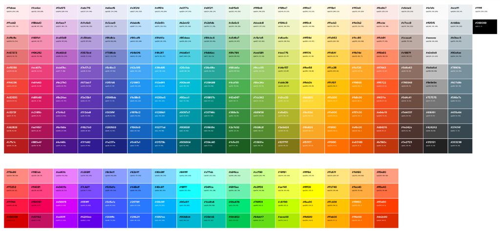

## Color

### Getting HEX codes

- In software (e.g., PowerPoint, Illustrator, Inkscape)
- Online (e.g., [Google](https://g.co/kgs/YAVBHVg), [HTML color codes](https://htmlcolorcodes.com/color-chart/), [coolers](https://coolors.co/))

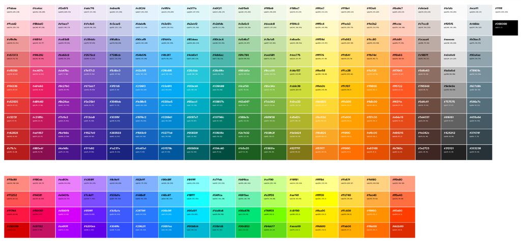

## Color

### Color accessibility is important!

The more color contrast the better!

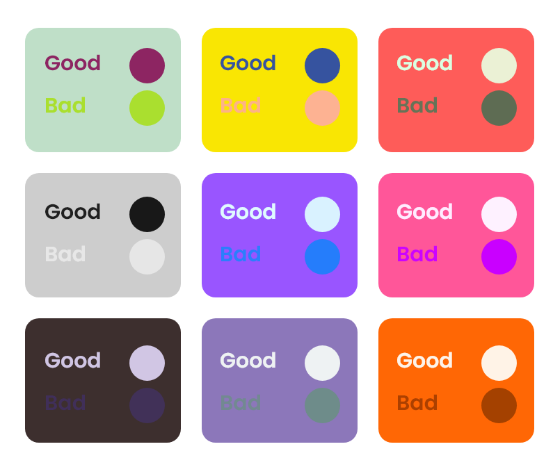

## Color

### Don’t forget about color blindness!

Check your graphs with a color blindness simulator (e.g., [ColourSimulations](http://www.coloursimulations.com/) or [ColorOracle](https://www.colororacle.org/)).

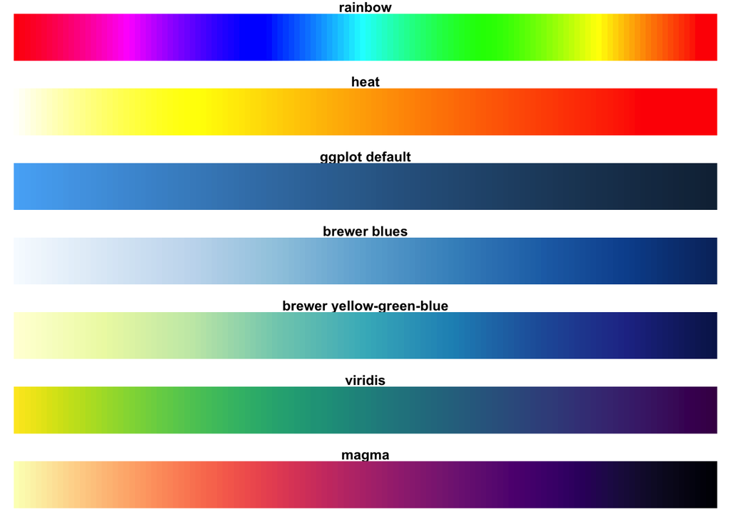

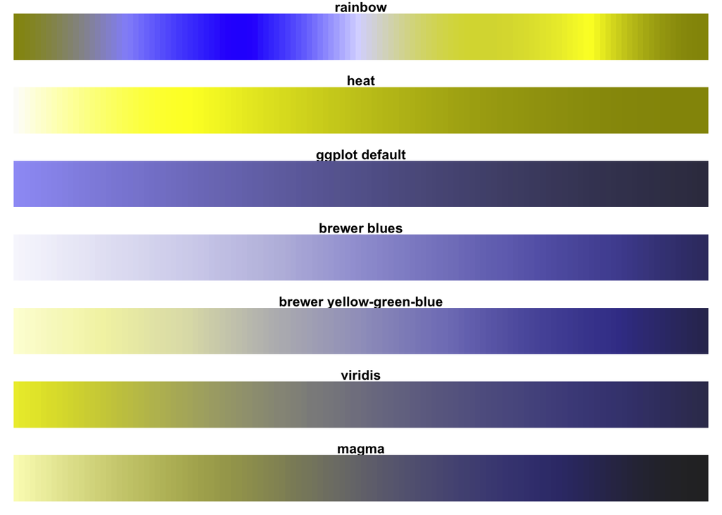

## Color

### Your graphs should even be legible in grayscale.

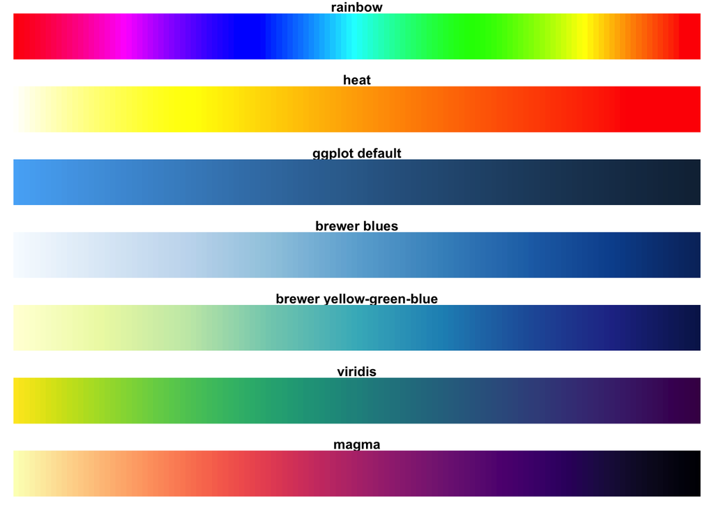

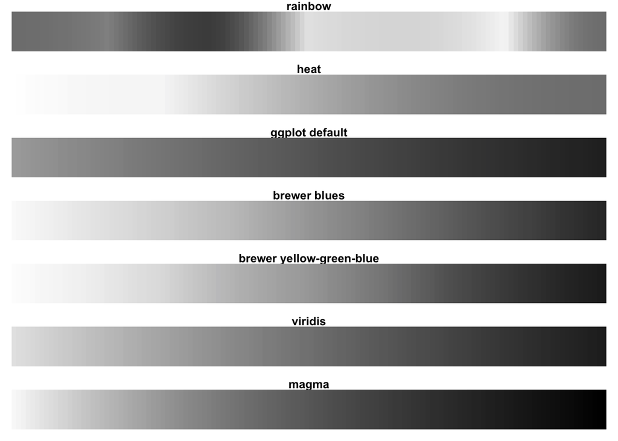

## Font

### There are lots of fonts/types, too!

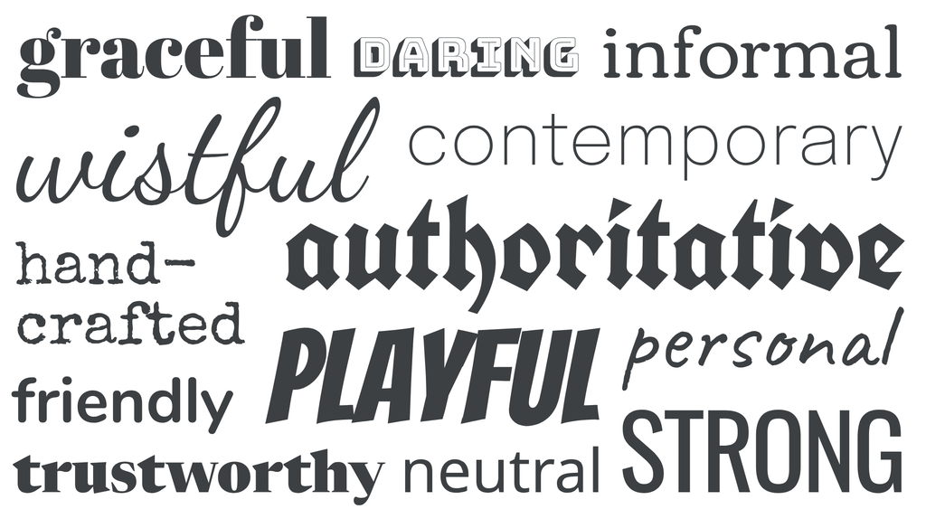

## Font

### We want easily readable fonts:

- Tahoma
- Calibri
- Helvetica
- Arial
- Find more at [Google Fonts](https://fonts.google.com/)
  - Can import these into R using the [`sysfonts` package](https://babichmorrowc.github.io/post/2019-10-11-google-fonts/)

## Font

### Tips

- One font is usually enough (max two)
- Make sure font size is big enough (who is the audience?)
- Use **bold** for emphasis, but avoid *italics* and underlines
- Left-aligned text is most readable
- Use size as a tool to hierarchize content
- Use 1.5 line spacing for better readability

# Picking a graph type

## Graph type depends on data type

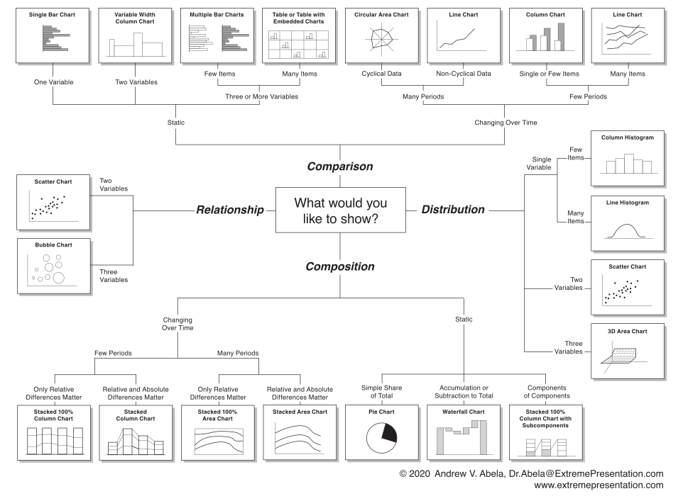

## Common mistakes

- Our brains cannot compare angles, so avoid pie charts

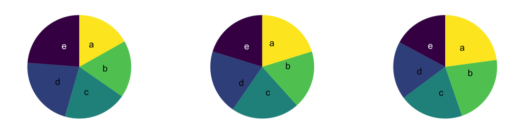

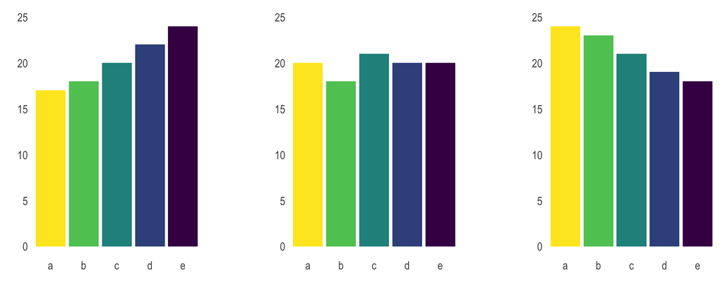

## Common mistakes

- Volumes and perspective can be tough too, so best to avoid 3D plots

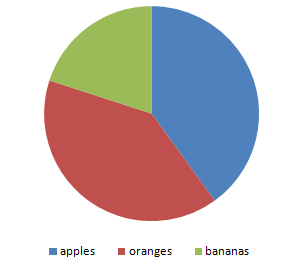

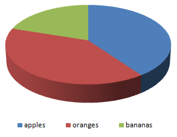

## Common mistakes

- Never truncate your X/Y axes or zoom on one part of them without showing the overall pattern as well

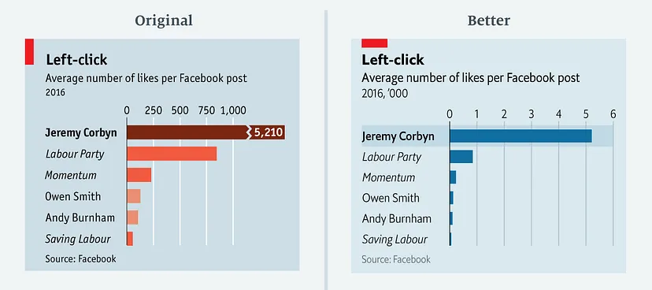

## Common mistakes

- Don’t overcomplicate your graphs!
  - Is the main point of the graph clear?

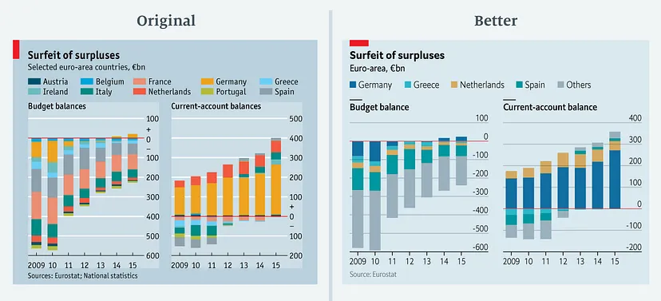

## Common mistakes

- Don’t overcomplicate your graphs!
  - Think about how much data to show

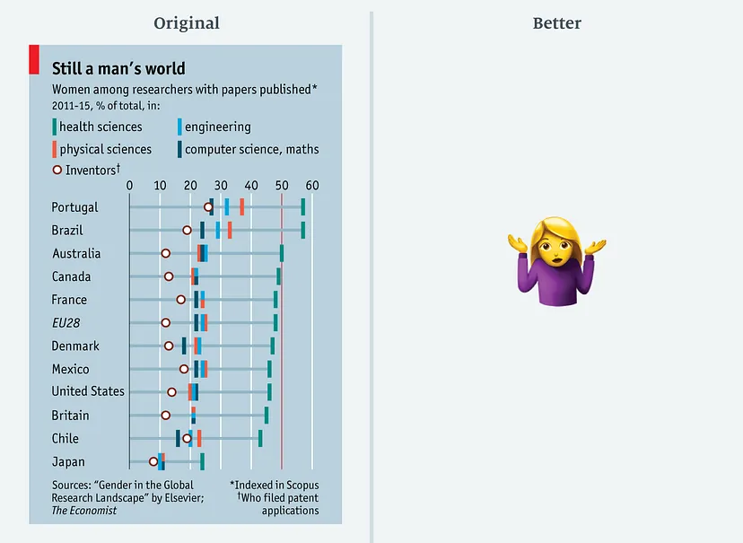

# Image and file types

## Image types

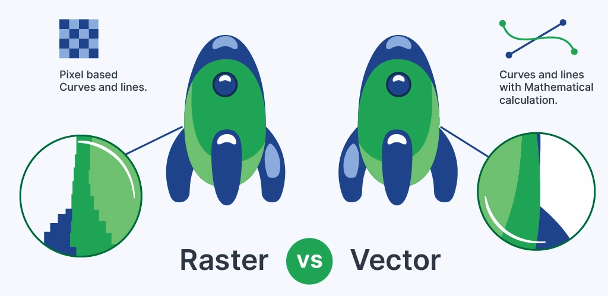

| Raster | Vector |
| --- | --- |
| Scale-dependent | Not scale-dependent |
| Large size files | Smaller size files |
| Not easily editable | Easily editable |
| Can have lots of detail | Usually fewer details/textures |
| Can not be converted easily to vector files | Can easily be converted to raster files |
| (e.g., made in Photoshop) | (e.g., made in Illustrator) |

## File formats

You can export plots from R in many file formats (we’ll mostly use `ggsave()`):

| File format | Image type | Notes |
| --- | --- | --- |
| .jpg | Raster | Can’t have transparent parts |
| .png | Raster | Can also have transparent parts |
| .svg | Vector | Can edit in Inkscape/Illustrator |
| .pdf | Vector | Not actually an image file type, but can be used |

# Visualization in R

http://cran.nexr.com/web/views/Graphics.html

## Visualization in R

### R already has lots of visualization functionality built-in:

- `plot()`
- `barplot()`
- `hist()`
- `boxplot()`
- `axis()`
- `legend()`
- `lines()`, `segments()`, `rect()`, `text()`, etc.

## Visualization in R

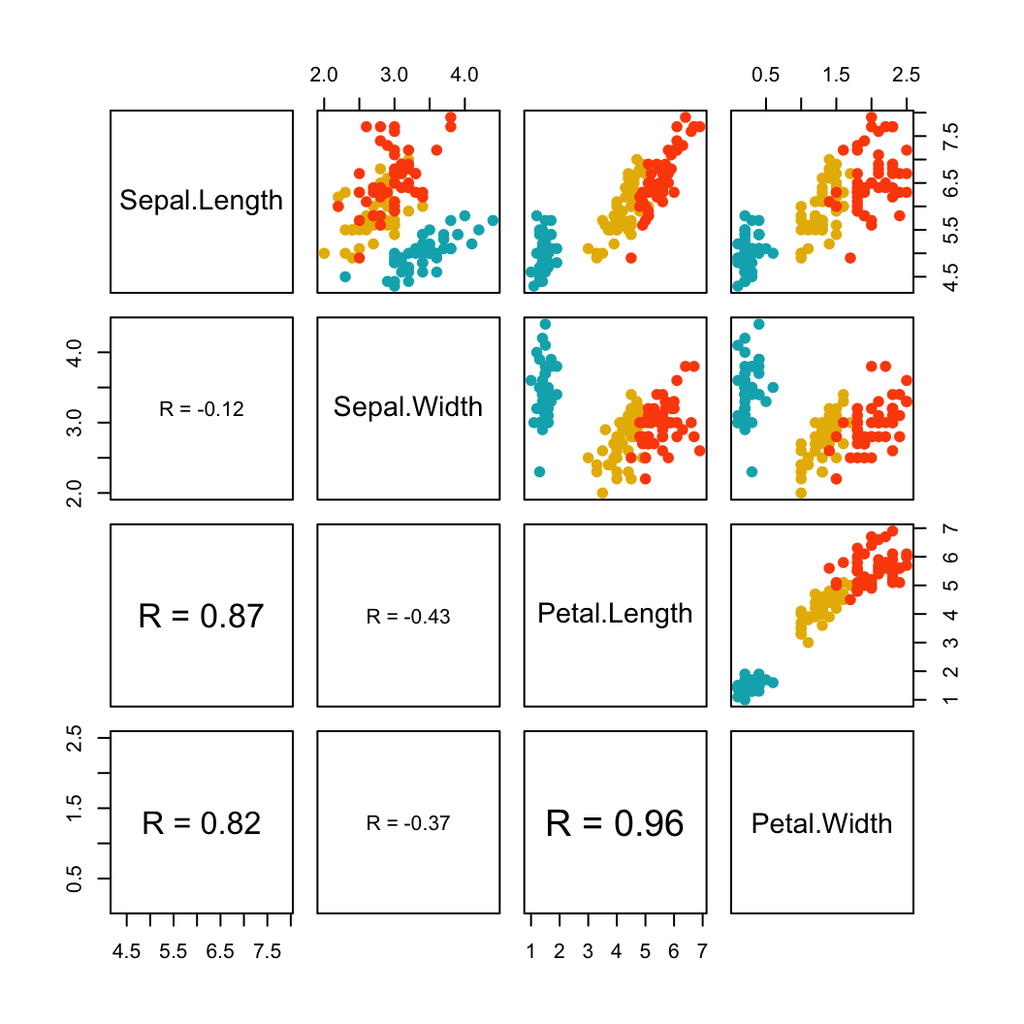

## Visualization in R

### Many packages build on these ‘base’ graphics:

- `{plotrix}`
- `{rgl}`: for 3D interactive graphics
- `{gplots}`
- `{scatterplot3d}`: 3D scatterplots
- `{palaeoverse}!`

## Visualization in R

### Then ‘grid’ graphics came along:

- More complex layouts
- Scaling is maintained on resizing
- Nested graphs and more interactivity

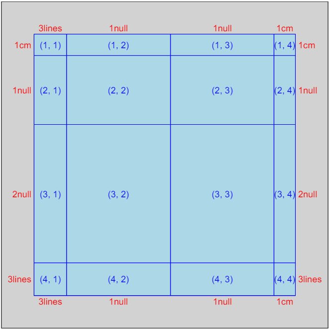

## Visualization in R

### Many packages build on these ‘grid’ graphics:

- `{lattice}`: trellis graphics
- `{vcd}`: for categorical data
- `{ggplot2}`: “grammar of graphics”
- `{hexbin}`: hexagonal bins
- `{patchwork}`: combine (ggplot2) plots
- `{deeptime}!`